# Barbod - Challenge Problem 3 Resubmission

## Challenge Problem 3 Resubmission

Barbod Khaleghi

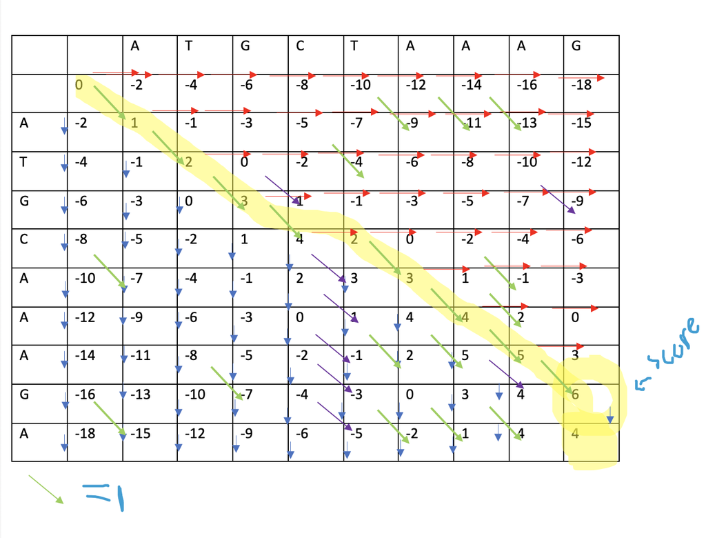

I also made an eroor on the Smith Waterman local alignment. Due to the previous one being incorrect, this one ended up with the wrong scores as well. After touching up on the local alignment, I was able to give the correct scores. This time I also included better arrows to indicate match, mismatch, and gap. This helped showed the flow to get the eventual 6 result as before. This was easier to visualise due to all the zeros, so you really can see the progress to the 6.

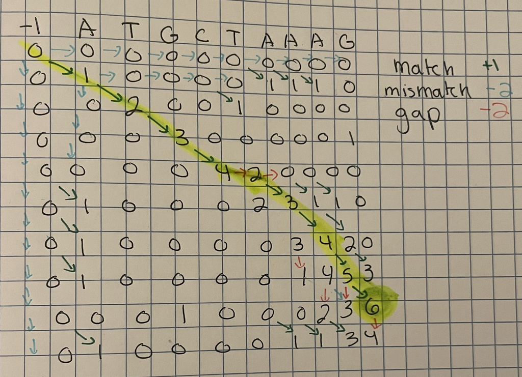

Next, I will go over my errors in the coding process. The code we submitted was incomplete as we could not import the fast file correctly. Thus, the entire code was unable to be ran. I have submitted our attempt below for refrence.

import Bio from Bio import SeqIO from Bio.Seq import Seq

DNAphosTau = SeqIO.read("GSK3B.fasta", "fasta") print(DNAphosTau) print(len(DNAphosTau))

DNAphosTau_seq = DNAphosTau.seq print(DNAphosTau_seq)

from Bio.Blast import NCBIWWW result_handle = NCBIWWW.qblast("blastn", "nt", DNAphosTau_seq) print(result_handle)

with open('results.xml', 'w') as save_file:

> > > blast_results = result_handle.read() save_file.write(blast_results)

BLAST_hit = "ATGTCAGGGCGGCCCAGAACCACCTCCTTTGCGGAGAGCTGCAAGCCGGTGCAGCAGCCT…" BLAST_hit_seq = Seq(BLAST_hit) print(BLAST_hit_seq)

import numpy as np import matplotlib as plt import matplotlib.pyplot as pltpy

def fillMatrix(M): ct = 0 M[0][0]= " " for r in range(1, M.shape[0]): for c in range(1, M.shape[1]): if M[r][0]== M[0][c]: M[r][c]="*" if r == c: ct += 1 else: M[r][c] = " " incorr = M.shape[0] - ct - 1 print("Number of aligned bases:", ct) print("Number of unaligned bases:", incorr, "\n")

def fill_print(): D = np.zeros([len(sequence1)+1, len(sequence2)+1],dtype=str) for r in range(0, len(sequence1)): D[r+1][0] = sequence1[r:r+1] for c in range(0, len(sequence2)): D[0][c+1] = sequence2[c:c+1] fillMatrix(D) print(D)

def fill_plot(): D = np.zeros([len(sequence1)+1, len(sequence2)+1],dtype=str) for r in range(0, len(sequence1)): D[r+1][0] = sequence1[r:r+1] for c in range(0, len(sequence2)): D[0][c+1] = sequence2[c:c+1] fillMatrix(D)

cmap = plt.colors.ListedColormap(['black', 'white']) bounds = [0,0.5,1] norm = plt.colors.BoundaryNorm(bounds, cmap.N)

fig, ax = pltpy.subplots(figsize=(10, 10), dpi=70) D_red = np.delete(D, 0, axis=1) D_red = np.delete(D_red, 0, axis=0) D_red_log = D_red == "*" ax.imshow(D_red_log, cmap=cmap, norm=norm)

sequence1 = "ATGTCAGGGCGGCCCAGAACCACCTCCTTTGCGGAGAGCTGCAAGCCGGTGCAGCAGCCT…" sequence2 = "ATGTCAGGGCGGCCCAGAACCACCTCCTTTGCGGAGAGCTGCAAGCCGGTGCAGCAGCCT…" fill_print()

sequence1 = "ATGTCAGGGCGGCCCAGAACCACCTCCTTTGCGGAGAGCTGCAAGCCGGTGCAGCAGCCT…" sequence2 = "ATGTCAGGGCGGCCCAGAACCACCTCCTTTGCGGAGAGCTGCAAGCCGGTGCAGCAGCCT…" fill_plot()

CPW5 = SeqIO.read("ChallengeProblem_Week5", "fasta") print(CPW5) print(len(CPW5))

#### New Code

Here, I will write all the new code to complete this challenge problem and reflect on what I did wrong on the challenge problem before.

Firstly, I did import some of these packages but was missing about half of them which were crucial to be used later.

```python
from Bio import SeqIO
import numpy as np
import matplotlib.pyplot as plt
from Bio import pairwise2
from Bio.Seq import Seq
```

Here, I had previously done this part correctly.

```python
GSK3B_gene = SeqIO.read("GSK3B.fasta.txt", "fasta")
print(GSK3B_gene)
print(len(GSK3B_gene))
GSK3B_gene_seq = GSK3B_gene.seq
print(GSK3B_gene_seq)
```

```
ID: lcl|NM_001146156.2_cds_NP_001139628.1_1
Name: lcl|NM_001146156.2_cds_NP_001139628.1_1
Description: lcl|NM_001146156.2_cds_NP_001139628.1_1 [gene=GSK3B] [db_xref=CCDS:CCDS54628.1] [protein=glycogen synthase kinase-3 beta isoform 2] [protein_id=NP_001139628.1] [location=1014..2276] [gbkey=CDS]
Number of features: 0
Seq('ATGTCAGGGCGGCCCAGAACCACCTCCTTTGCGGAGAGCTGCAAGCCGGTGCAG...TGA')
1262
ATGTCAGGGCGGCCCAGAACCACCTCCTTTGCGGAGAGCTGCAAGCCGGTGCAGCAGCCT…
```

On my first attempt, I inputted all of the correct code for these next two chunks to work correctly and I was able to somewhat run the BLAST search. To do this, I had to import all proper packages and ensuring I had the fasta file properly imported. What we are doing here is esentially running a BLAST like we did in the previous challenge problem. The BLAST NCBIWWW module was ran to search the internet and qblast funtion was called and stored as the result_handle variable. Then, with this, the result_hand was used to write the result and store it as the xml file.

```python
from Bio.Blast import NCBIWWW
result_handle = NCBIWWW.qblast("blastn", "nt", GSK3B_gene_seq)
print(result_handle)
```

```
<_io.StringIO object at 0x7f8e44eee1f0>
```

```python
with open('GSK3B_BLASTresults.xml', 'w') as save_file:
    blast_results = result_handle.read()
    save_file.write(blast_results)
```

Previously, I did not do the next step and thus the code was unable to be run as was seen from my result. The next step consisted of importing the NCBIXML package this time to work with the xml file that I had just created. Using the NCBIXML.read after opening the xml file, the content was stored as the variable blast_record to be used later. The hit title and hit.e was printed so that we could better understand the description of th eblast record we had just accessed and were working with.

```python
from Bio.Blast import NCBIXML
handle = open("GSK3B_BLASTresults.xml")
blast_record = NCBIXML.read(handle)
```

```python
for hit in blast_record.descriptions:
    print(hit.title)
    print(hit.e)
```

```
gi|1677501709|ref|NM_001146156.2| Homo sapiens glycogen synthase kinase 3 beta (GSK3B), transcript variant 2, mRNA
0.0
gi|158255229|dbj|AK290897.1| Homo sapiens cDNA FLJ75266 complete cds, highly similar to Homo sapiens glycogen synthase kinase 3 beta, mRNA
0.0
gi|39644670|gb|BC012760.2| Homo sapiens glycogen synthase kinase 3 beta, mRNA (cDNA clone MGC:16182 IMAGE:3637163), complete cds
0.0
gi|49168505|emb|CR536510.1| Homo sapiens full open reading frame cDNA clone RZPDo834A0920D for gene GSK3B, glycogen synthase kinase 3 beta; complete cds, incl. stopcodon >gi|162423649|gb|EU302497.1| Homo sapiens GSK3beta isoform (GSK3B) mRNA, complete cds
0.0
gi|1849117106|ref|XM_003825159.4| PREDICTED: Pan paniscus glycogen synthase kinase 3 beta (GSK3B), transcript variant X2, mRNA
0.0
gi|168277849|dbj|AB385047.1| Synthetic construct DNA, clone: pF1KB5120, Homo sapiens GSK3B gene for glycogen synthase kinase-3 beta, complete cds, without stop codon, in Flexi system
0.0
gi|1034158765|ref|XM_016941721.1| PREDICTED: Pan troglodytes glycogen synthase kinase 3 beta (GSK3B), transcript variant X2, mRNA
0.0
gi|529236|gb|L33801.1|HUMGLSYKIN Human protein kinase mRNA, complete cds
0.0
gi|197692412|dbj|AB451356.1| Homo sapiens GSK3B mRNA for glycogen synthase kinase-3 beta, partial cds, clone: FLJ08025AAAF
0.0
gi|1753064737|ref|XM_019024078.2| PREDICTED: Gorilla gorilla gorilla glycogen synthase kinase 3 beta (GSK3B), transcript variant X3, mRNA
0.0
gi|1799970238|ref|XM_032150082.1| PREDICTED: Hylobates moloch glycogen synthase kinase 3 beta (GSK3B), transcript variant X2, mRNA
0.0
gi|1743191970|ref|XM_004091710.3| PREDICTED: Nomascus leucogenys glycogen synthase kinase 3 beta (GSK3B), transcript variant X2, mRNA
0.0
gi|1351493380|ref|XM_024244580.1| PREDICTED: Pongo abelii glycogen synthase kinase 3 beta (GSK3B), transcript variant X2, mRNA
0.0
gi|1777297756|ref|XM_021933111.2| PREDICTED: Papio anubis glycogen synthase kinase 3 beta (GSK3B), transcript variant X9, mRNA
0.0
gi|1751190964|ref|XM_030941605.1| PREDICTED: Rhinopithecus roxellana glycogen synthase kinase 3 beta (GSK3B), transcript variant X2, mRNA
0.0
gi|1938857894|ref|XM_007985674.2| PREDICTED: Chlorocebus sabaeus glycogen synthase kinase 3 beta (GSK3B), transcript variant X2, mRNA
0.0
gi|1411134873|ref|XM_025375801.1| PREDICTED: Theropithecus gelada glycogen synthase kinase 3 beta (GSK3B), transcript variant X2, mRNA
0.0
gi|795296674|ref|XM_012068443.1| PREDICTED: Cercocebus atys glycogen synthase kinase 3 beta (GSK3B), transcript variant X2, mRNA
0.0
gi|795170885|ref|XM_011987169.1| PREDICTED: Mandrillus leucophaeus glycogen synthase kinase 3 beta (GSK3B), transcript variant X2, mRNA
0.0
gi|795157884|ref|XM_011940645.1| PREDICTED: Colobus angolensis palliatus glycogen synthase kinase 3 beta (GSK3B), transcript variant X2, mRNA
0.0
```

[output cut: 45 more lines]

```
0.0
gi|1804825911|ref|XM_032347633.1| PREDICTED: Mustela erminea glycogen synthase kinase 3 beta (GSK3B), transcript variant X2, mRNA
0.0
gi|1244073772|ref|XM_022507209.1| PREDICTED: Enhydra lutris kenyoni glycogen synthase kinase 3 beta (LOC111149921), transcript variant X2, mRNA
0.0
gi|2223452467|ref|XM_047725988.1| PREDICTED: Lutra lutra glycogen synthase kinase-3 beta (LOC125097853), transcript variant X2, mRNA
0.0
gi|2130903670|ref|XM_004772792.3| PREDICTED: Mustela putorius furo glycogen synthase kinase 3 beta (GSK3B), transcript variant X2, mRNA
0.0
gi|2124518810|ref|XM_044771530.1| PREDICTED: Equus asinus glycogen synthase kinase 3 beta (GSK3B), transcript variant X3, mRNA
0.0
gi|472368098|ref|XM_004403521.1| PREDICTED: Odobenus rosmarus divergens glycogen synthase kinase 3 beta (GSK3B), transcript variant X2, mRNA
0.0
gi|1900007242|ref|XM_036111758.1| PREDICTED: Halichoerus grypus glycogen synthase kinase 3 beta (GSK3B), transcript variant X2, mRNA
0.0
```

I also did not do this part previously as I did not know about the Entrez system and its capabilities. Here, I first imported Entrez so that I could access a variety of biological databases on the internet. This could be done using the professor's email to gain access. Once this module was imported, I was able to use Entrez.efetch to get the specified gene I am examining using its id and scouring the nucleotide database. With this, I was able to print the BLAST record found after turning it into a seq using the .seq function. Each step I set variables to define the gene being accessed.

```python
from Bio import Entrez
Entrez.email = "jmschiffer@ucsd.edu"
```

```python
handle = Entrez.efetch(db="nucleotide", id="1753064737", rettype="gb", retmode="text")
record = SeqIO.read(handle, "genbank")
BLAST_Hit = record.seq
print(BLAST_Hit)
```

```
ACACAGAGCAGCCCCTGACCCGGGCGAATGCGGGCTTGTGCCGCCGCCGCCGCCGCCGCC…
```

Since, we were unable to run a BLAST search effectively, I was unable to complete the next part as well and am missing all of the following code coming up. We had some code for trying to define the variables and create a dot plot but came up empty when no plot was shown on the display. The proper way to create the dot plot is shown below. First, I had to se the window size and the axises. The window variable was used to do so as well as seq_one and seq_two were used to set the axis as the original gene and the BLAST gene found. Then, a for loop was used to create the data needed to finalize the plot. In the for loop the variables were arranged together to optimize the sequence formation. This helped create the range of the plot in accordance to the difference on the seqeunce and the window size.

```python
window = 3
seq_one = str(GSK3B_gene_seq)
seq_two = str(BLAST_Hit)
data = [
    [
        (seq_one[i : i + window] != seq_two[j: j + window])
        for j in range(len(seq_one) - window)
    ]
    for i in range(len(seq_two) - window)
]

print(data)
```

[output not shown]

For this part, we previously did do something somewhat similar trying to use plt instead pf pylab, however. In this case, pylab is ideal for forming the plot. Here, I was just created all the base necessities of the plot. This included setting the x axis, y axis, title, and overall showing the data. Thus, the plot was created that showed a dot plot using window size 3 that allowed no mis-matches. This plot was the result of the previous chunks data as well and was construncted using the record of the BLAST search and GSK3B gene id.

[figure not shown]

```python
import pylab

pylab.gray()
pylab.imshow(data)
pylab.xlabel("%s (length %i bp)" % (GSK3B_gene.id, len(GSK3B_gene_seq)))
pylab.ylabel("%s (length %i bp)" % (record.id, len(BLAST_Hit)))
pylab.title("Dot plot using window size %i\n(allowing no mis-matches)" % window)
pylab.show()
```

This is the last chunk of the assignment. We did not reach this accurately as we were unable to properly import the new package. The instructor told me that the problem was the need to convert this into a list first. To solve, the reading of the fasta file of before, I had to use the list command and SeqIO.parse to properly gain this new package.

```python
Fasta = list(SeqIO.parse("ChallengeProblem_Week5.fasta", "fasta"))
```

The next few parts were not done at all by us due to being unable to import the fasta file so there is no previous work to compare to. To complete this next part though, all that had to be done was to take the length of the Fasta file using the len function and initiliaze the an empty numpy matrix to be equivalent to the lenght of the imported fasta file. This can help to set the range for later on.

```python
size = len(Fasta)
alignments_score = np.empty(shape=(size,size))
```

In this instance, we were unable to do this part as well but I learned how to fully completed the heat map. Firstly, the pairwise sequence heatmap was defined through creating a nested for loop in which doing a pairwise alignment was possible for each pair of kinases. The for loop first loops over the kinases and then does it again to go over all kinases. Then, the two sequences, variables X and Y, were aligned using .seq function with brackets to set them as the axises in heatmap and make sure they are properly aligned. Furthermore, then I initialize the int function set to my_numpy_array[i,j] with the brackets there to represent the for loop statements. In doing so, I got a list of the global alignments of the two sequences. By doing so, I was able to set no gaps and no parameters. Then used the return command to return what had just been globally aligned. Then, I set that created plot to the variable My_alignment_Scores to check that the matrix had been created through the for loop. Once that is all finished, the ploit can be created. First, a subplot was made using plt.subplots() function. Then, the axises were set to be present while constructing the heatmap. Lastly, plt.show() enabled the plot to be displayed.

```python
def pairwise_seq_heatmap(my_numpy_array, size):
    for i in range(size):
        for j in range(size):
            X = Fasta[i].seq
            Y = Fasta[j].seq
            my_numpy_array[i,j] = int(pairwise2.align.globalxx(X, Y, score_only=True))
    return my_numpy_array
My_alignment_Scores = pairwise_seq_heatmap(alignments_score, size)
```

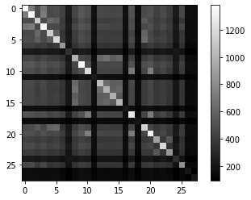

```python
fig, ax = plt.subplots()
plt.imshow(alignments_score)
im = ax.imshow(alignments_score)
cbar = ax.figure.colorbar(im)
plt.show()
```